# PerSnpVignette

Here, we show how we can compute the prior weights on a large number of gene snp pairs and compute the weighted quanities one snp at a time.

[output not shown]

```r
set.seed(123)
R=5
covdat = factor_sim(n=1000,K=10,betasd=1,esd=0.3,d=5)
b.gp.hat=covdat$betahat
se.gp.hat=covdat$sebetahat
t.stat=covdat$tstat

lambda.mat=covdat$lambda
factor.mat=covdat$factors
covmat=compute.covmat(b.gp.hat,se.gp.hat,Q=5,t.stat,lambda.mat=lambda.mat,P=2,A="simulation",factor.mat=factor.mat,bma=TRUE)

K=length(covmat)
K
```

```
## [1] 315
```

```r
covmat[[K]]
```

```
##          [,1]     [,2]     [,3]     [,4]     [,5]
## [1,] 12.87144 12.87144 12.87144 12.87144 12.87144
## [2,] 12.87144 12.87144 12.87144 12.87144 12.87144
## [3,] 12.87144 12.87144 12.87144 12.87144 12.87144
## [4,] 12.87144 12.87144 12.87144 12.87144 12.87144
## [5,] 12.87144 12.87144 12.87144 12.87144 12.87144
```

Now, we let’s remove these strong tstats and split simulate new data into test and training. This will compute the HM weights on training data and return a file of likelihoods for the training data. I use my factor simulator to simulate true betas and betahats. Note that we want only the rownames to include meta data (and not an additional column) because this will impace the dimension compatibility of the prior covariance matrices and V.

```r
rm(b.gp.hat)
rm(se.gp.hat)

newdat = factor_sim(n=10000,K=10,betasd=0.5,esd=0.3,d=5)
b.hat=newdat$betahat
se.hat=newdat$sebetahat


##Not
indices=seq(1,nrow(b.hat))
rownames(b.hat)=paste("gene_snp",indices,sep="")##now, we want our data frame to have rownames

J=nrow(b.hat)
head(b.hat)
```

```
##                  [,1]       [,2]        [,3]       [,4]        [,5]
## gene_snp1 -1.21731667  1.0488980  0.59248181 -0.1855839  0.20602293
## gene_snp2 -0.23356795  0.3027430 -0.23347767  0.4904415  0.31481798
## gene_snp3 -0.12661970  0.1914189 -0.06265232  0.4030229 -0.20199262
## gene_snp4  0.04966044  0.4812022  0.22135758  0.3164324 -0.42049187
## gene_snp5 -0.57205136  0.2582436 -0.03715164 -0.8196267  0.53363803
## gene_snp6 -0.13959098 -0.4640922 -0.61882344 -0.1015511 -0.09465456
```

Now, we separate into training data. I will train on 1000 gene snp Pairs.

```r
b.train=b.hat[1:1000,]
se.train=se.hat[1:1000,]

compute.hm.train(train.b = b.train,se.train = se.train,covmat = covmat,A="Simulations")
```

```r
##compute the HM weights on training data
##check to show that the likelihood computatations are correct
A="Simulations"
likmat=readRDS(paste0("liketrain",A,".rds"))
likmat[1,1:10]
```

```
##  [1] 2.958083e-06 2.436582e-06 2.698748e-06 1.033388e-06 2.116979e-06
##  [6] 1.149237e-06 2.714728e-06 7.044595e-07 2.462118e-06 1.886779e-06
```

```r
lik.func(b.mle = b.train[1,],V.gp.hat = diag(se.train[1,])^2,covmat)[1:10]
```

```
##  [1] 2.958083e-06 2.436582e-06 2.698748e-06 1.033388e-06 2.116979e-06
##  [6] 1.149237e-06 2.714728e-06 7.044595e-07 2.462118e-06 1.886779e-06
```

Note creation of three files: pis, a pdf of pis, and a matrix of likelihoods of training data. Now,we remove the training data and create our test data. We can see that it contains the gene snp pairs in the rows and the standardized effect across subgroups in the columns.

```r
rm(b.train)
rm(se.train)

b.test=b.hat[1001:nrow(b.hat),]
se.test=se.hat[1001:nrow(se.hat),]
b.truth.test=newdat$beta[1001:nrow(b.hat),]
```

We read in the previously computed pis and the covariane matrix and compute the test likelihood and corresponding weights. Note the return of a file of test likeilihoods and posterior weights. Here, I will only do the computation for 100 gene-snp pairs.

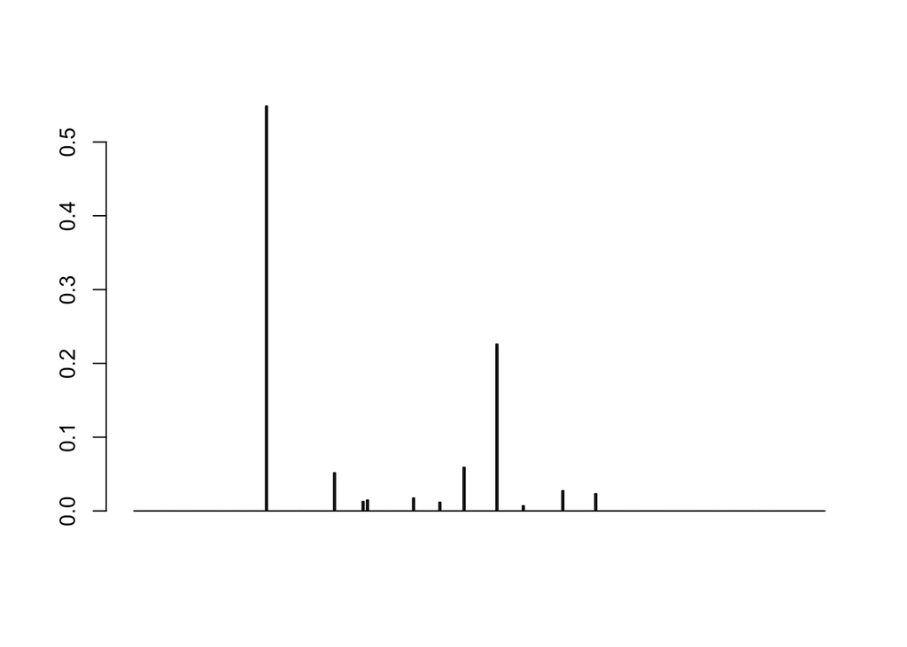

```r
A="Simulations"
pis=readRDS(paste0("pis",A,".rds"))$pihat

barplot(t(as.matrix(pis)))
```

```r
(covmat[[which.max(pis)]])
```

```
##            [,1]       [,2]       [,3]       [,4]       [,5]
## [1,] 0.05027906 0.00000000 0.00000000 0.00000000 0.00000000
## [2,] 0.00000000 0.05027906 0.00000000 0.00000000 0.00000000
## [3,] 0.00000000 0.00000000 0.05027906 0.00000000 0.00000000
## [4,] 0.00000000 0.00000000 0.00000000 0.05027906 0.00000000
## [5,] 0.00000000 0.00000000 0.00000000 0.00000000 0.05027906
```

Now, we can compute the posterior quanitites for each gene snp pair. Here, we’ll test it on 100 gene snp pairs.

```r
weightedquants=lapply(seq(1:100),function(j){total.quant.per.snp(j,covmat,b.gp.hat=b.test,se.gp.hat = se.test,pis,A="Simulations",checkpoint = FALSE)})
```

Note that we create a file of posterior weighted means, lfsr and marginal variances.

To make sure that these computations are correct,

```r
j=sample.int(100,1)
all.arrays=post.array.per.snp(j=j,covmat = covmat,b.gp.hat = b.test,se.gp.hat = se.test)

b.mle=as.vector(t(b.test[j,]))##turn i into a R x 1 vector
V.gp.hat=diag(se.test[j,])^2
V.gp.hat.inv <- solve(V.gp.hat)
k=17

U.gp1kl <- (post.b.gpkl.cov(V.gp.hat.inv, covmat[[k]]))
(mu.gp1kl <- as.array(post.b.gpkl.mean(b.mle, V.gp.hat.inv, U.gp1kl)))
```

```
##             [,1]
## [1,]  0.03735349
## [2,]  0.03639983
## [3,] -0.06624649
## [4,] -0.11290050
## [5,] -0.05046507
```

```r
(all.arrays$post.means[k,])
```

```
## [1]  0.03735349  0.03639983 -0.06624649 -0.11290050 -0.05046507
```

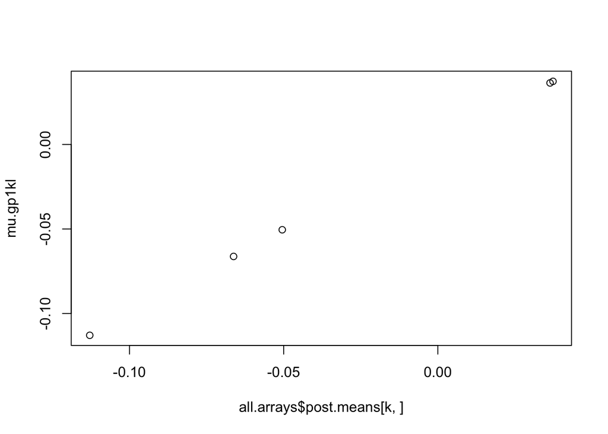

```r
plot(all.arrays$post.means[k,],mu.gp1kl)
```

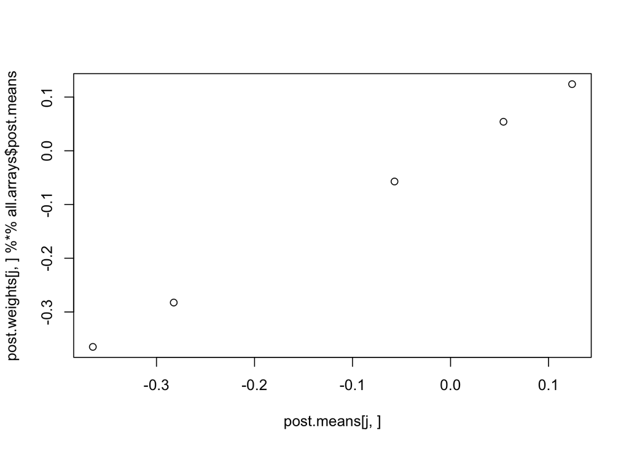

```r
##Now, check to make sure weighting is correct
post.means=as.matrix(read.table(paste0(A,"posterior.means.txt"))[,-1])
post.weights=as.matrix(read.table(paste0(A,"post.weights.txt"))[,-1])

plot(post.means[j,],post.weights[j,]%*%all.arrays$post.means)
```

```r
(post.means[j,])
```

```
##          V2          V3          V4          V5          V6
##  0.05399066  0.12402850 -0.28243243 -0.36496844 -0.05717366
```

```r
(post.weights[j,]%*%all.arrays$post.means)
```

```
##            [,1]      [,2]       [,3]       [,4]        [,5]
## [1,] 0.05399066 0.1240285 -0.2824324 -0.3649684 -0.05717366
```

And observe the beautiful shrinkage!! And proof that our method is strongly correlated with original summary statistics.

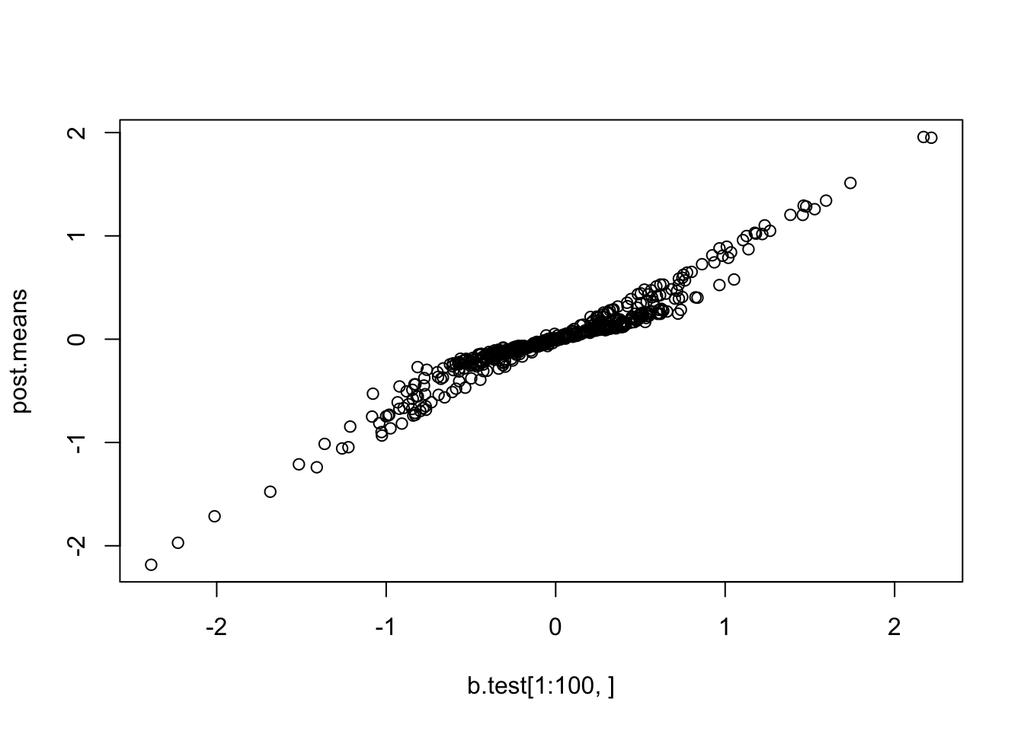

```r
plot(b.test[1:100,],post.means)
```

```r
cor(as.vector(as.matrix(b.test[1:100,])),as.vector(as.matrix(post.means)))
```

```
## [1] 0.9633232
```